# HW_3_DATA606_ALEXANDER_NICULESCU

alexander

9/25/2018

Chapter 3 - Distributions of Random Variables Practice: 3.1 (see normalPlot), 3.3, 3.17 (use qqnormsim from lab 3), 3.21, 3.37, 3.41 Graded: 3.2 (see normalPlot), 3.4, 3.18 (use qqnormsim from lab 3), 3.22, 3.38, 3.42

3.2 Area under the curve, Part II. What percent of a standard normal distribution N(μ =0, σ = 1) is found in each region? Be sure to draw a graph. (a) Z > σ 1.13 (b) Z <0.18 (c) Z > 8 (d) |Z| < 0.5

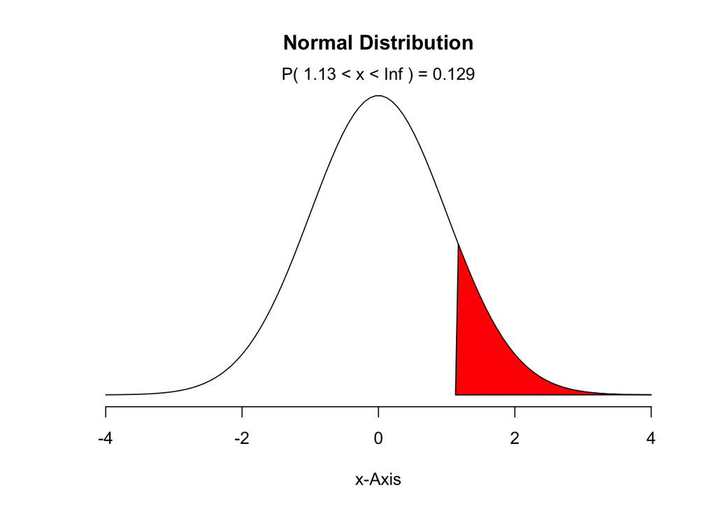

```r
normalPlot(bounds=(c(1.13,Inf)))
```

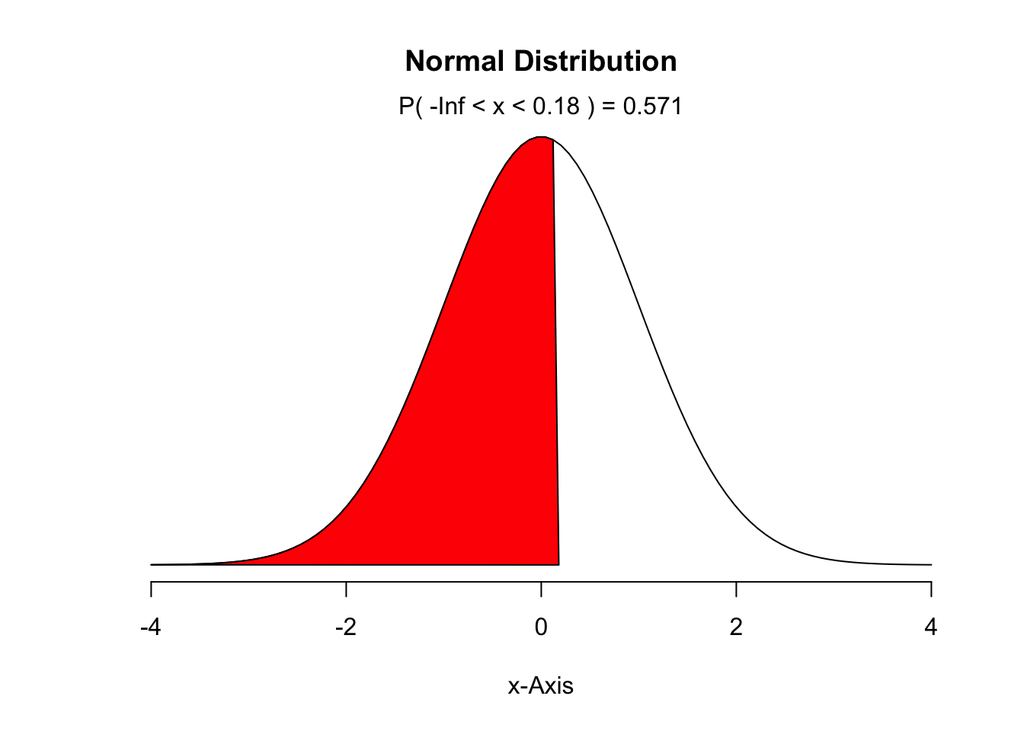

```r
normalPlot(bounds=(c(-Inf,.18)))
```

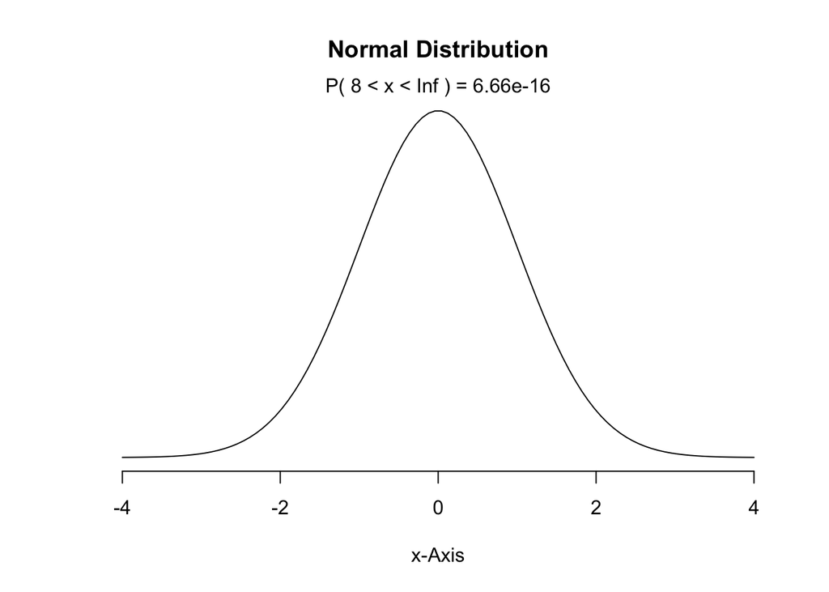

```r
normalPlot(bounds=(c(8,Inf)))
```

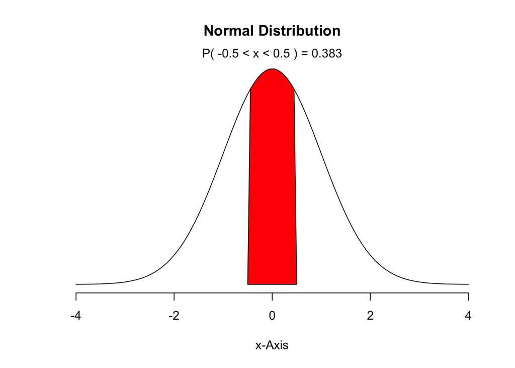

```r
normalPlot(bounds=(c(-.5, .5)))
```

3.4 Triathlon times, Part I. In triathlons, it is common for racers to be placed into age and gender groups. Friends Leo and Mary both completed the Hermosa Beach Triathlon, where Leo competed in the Men, Ages 30 - 34 group while Mary competed in the Women, Ages 25 - 29 group. Leo completed the race in 1:22:28 (4948 seconds), while Mary completed the race in 1:31:53 (5513 seconds). Obviously Leo finished faster, but they are curious about how they did within their respective groups. Can you help them? Here is some information on the performance of their groups: • The finishing times of the Men, Ages 30 - 34 group has a mean of 4313 seconds with a standard deviation of 583 seconds. • The finishing times of the Women, Ages 25 - 29 group has a mean of 5261 seconds with a standard deviation of 807 seconds. • The distributions of finishing times for both groups are approximately Normal. Remember: a better performance corresponds to a faster finish. (a) Write down the short-hand for these two normal distributions. M(μ, σ) = 4313, 583 F(μ, σ) = 5261, 807 (b) What are the Z-scores for Leo’s and Mary’s finishing times? What do these Z-scores tell you?

```r
zLeo  <- (4948 - 4313)/583
zMary <- (5513 - 5261)/807
cat("ZSCORE FOR LEO:", zLeo)
```

```
## ZSCORE FOR LEO: 1.089194
```

```r
cat("ZSCORE FOR MARY:", zMary)
```

```
## ZSCORE FOR MARY: 0.3122677
```

3. Did Leo or Mary rank better in their respective groups? Explain your reasoning. (Same answer for b) These scores tell me ary did better than Leo, her zscore was less than 1SD from the mean.
4. What percent of the triathletes did Leo finish faster than in his group?
5. What percent of the triathletes did Mary finish faster than in her group?

```r
LeoPercent <- 1-pnorm(zLeo)
MaryPercent <-1-pnorm(zMary)

cat("Leo's Time Was Faster than:",  LeoPercent, "Percent of runners")
```

```
## Leo's Time Was Faster than: 0.1380342 Percent of runners
```

```r
cat("Mary's Time Was Faster than:", MaryPercent, "Percent of runners")
```

```
## Mary's Time Was Faster than: 0.3774186 Percent of runners
```

6. If the distributions of finishing times are not nearly normal, would your answers to parts (b) - (e) change? Explain your reasoning. Yes, if the distributions were different, the mean would still hold, but the z scores wouldn’t make much sense because the left and right side of the curves wouldn’t be symmetrical.

3.18 Heights of female college students. Below are heights of 25 female college students. 54, 55, 56, 56, 57, 58, 58, 59, 60, 60, 60, 61, 61, 62, 62, 63, 63, 63, 64, 65, 65, 67, 67, 69, 73 (a) The mean height is 61.52 inches with a standard deviation of 4.58 inches. Use this information to determine if the heights approximately follow the 68-95-99.7% Rule.

```r
heightsOfFemales <- c(54, 55, 56, 56, 57, 58, 58, 59, 60, 60, 60, 61, 61, 62, 62, 63, 63, 63, 64, 65, 65, 67, 67, 69, 73)
summary(heightsOfFemales)
```

```
##    Min. 1st Qu.  Median    Mean 3rd Qu.    Max.
##   54.00   58.00   61.00   61.52   64.00   73.00
```

```r
mean<- 61.52
sd <-  4.58

onesd   <- pnorm(mean+(1 * sd), mean, sd) - pnorm(mean - (1 * sd), mean, sd)
twosd   <- pnorm(mean+(2 * sd), mean, sd) - pnorm(mean - (2 * sd), mean, sd)
threesd <- pnorm(mean+(3 * sd), mean, sd) - pnorm(mean - (3 * sd), mean, sd)

cat("Does One SD PASS:",   onesd, "YES")
```

```
## Does One SD PASS: 0.6826895 YES
```

```r
cat("Do Two SD's PASS:",   twosd, "YES")
```

```
## Do Two SD's PASS: 0.9544997 YES
```

```r
cat("Do Three SD's PASS:", threesd, "YES")
```

```
## Do Three SD's PASS: 0.9973002 YES
```

2. Do these data appear to follow a normal distribution? Explain your reasoning using the graphs provided below.

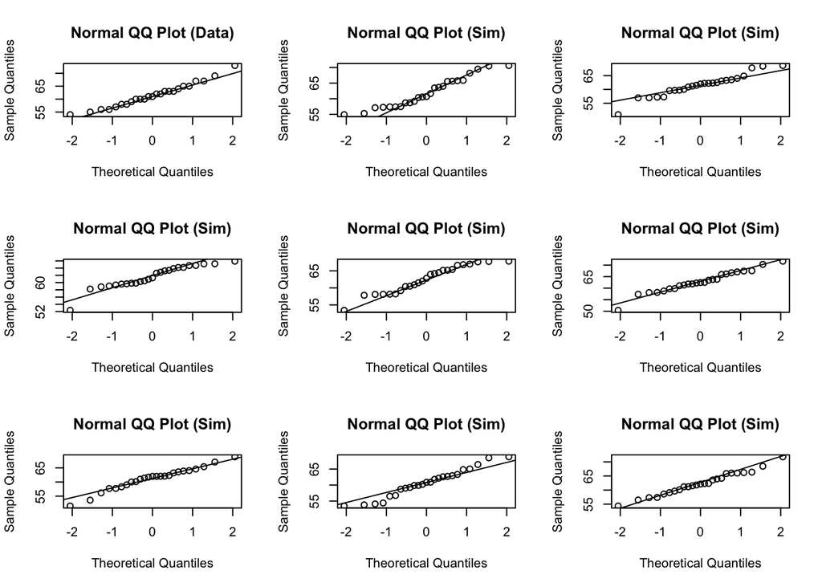

```r
qqnormsim(heightsOfFemales)
```

The trend is very close to the normal distribution according to the plots.

3.22 Defective rate. A machine that produces a special type of transistor (a component of computers) has a 2% defective rate. The production is considered a random process where each transistor is independent of the others. (b) What is the probability that the machine produces no defective transistors in a batch of 100? (c) On average, how many transistors would you expect to be produced before the first with a defect? What is the standard deviation? (d) Another machine that also produces transistors has a 5% defective rate where each transistor is produced independent of the others. On average how many transistors would you expect to be produced with this machine before the first with a defect? What is the standard deviation?

```r
failureProbA <- .02
failureProbB <- .05
successProbA <- 1 - failureProbA
successProbB <- 1 - failureProbB

#(a) What is the probability that the 10th transistor produced is the first with a defect?
print(successProbA^9*failureProbA)
```

```
## [1] 0.01667496
```

```r
#(b) What is the probability that the machine produces no defective transistors in a batch of 100?
successProbA^100
```

```
## [1] 0.1326196
```

3. On average, how many transistors would you expect to be produced before the first with a defect? What is the standard deviation? .02 is two in a hundred, so it would 2/100 or 1/50.  
   And the sd would be:

```r
print(sd <- sqrt((successProbA)/(failureProbA^2)))
```

```
## [1] 49.49747
```

4. Another machine that also produces transistors has a 5% defective rate where each transistor is produced independent of the others. On average how many transistors would you expect to be produced with this machine before the first with a defect? What is the standard deviation?

```r
failureProbB <- .05
successProbB <- 1 - failureProbB

#.05 is 5/100 or 1/20
print(sd <- sqrt((successProbB)/(failureProbB^2)))
```

```
## [1] 19.49359
```

3.38 Male children. While it is often assumed that the probabilities of having a boy or a girl are the same, the actual probability of having a boy is slightly higher at 0.51. Suppose a couple plans to have 3 kids. (a) Use the binomial model to calculate the probability that two of them will be boys.

```r
bothBoys <- ((choose(3,2) * (1-0.51) * (0.51^2)))

cat("The probability that two of them will be boys:", bothBoys)
```

```
## The probability that two of them will be boys: 0.382347
```

2. Write out all possible orderings of 3 children, 2 of whom are boys. Use these scenarios to calculate the same probability from part (a) but using the addition rule for disjoint outcomes.

```r
#bbg, bgb, gbb
bothBoysDisjoint <- 3 * (.51^2 * .49)
cat("The probability that two of them will be boys (disjoint):", bothBoysDisjoint)
```

```
## The probability that two of them will be boys (disjoint): 0.382347
```

3.42 Serving in volleyball. A not-so-skilled volleyball player has a 15% chance of making the serve, which involves hitting the ball so it passes over the net on a trajectory such that it will land in the opposing team’s court. Suppose that her serves are independent of each other. (a) What is the probability that on the 10th try she will make her 3rd successful serve?

```r
P = (.15)^3
oneMinusP = (.85)^7
n <- 10-1
k <- 3-1

out <- (choose(n,k)) * P * oneMinusP

print(out)
```

```
## [1] 0.03895012
```

2. Suppose she has made two successful serves in nine attempts. What is the probability that her 10th serve will be successful? It would be the same for the nth serve; P = .15
3. Even though parts (a) and (b) discuss the same scenario, the probabilities you calculated should be different. Can you explain the reason for this discrepancy? Part a is continuous, part b is discrete. The outcome of a is affected by previous instances, whereas b’s is isolated i.e. a coin toss.